# autoimage: Multiple Heat Maps for Projected Coordinates

Heat maps are commonly used to display the spatial distribution of a response observed on a two-dimensional grid. The *autoimage* package provides convenient functions for constructing multiple heat maps in unified, seamless way, particularly when working with projected coordinates. The *autoimage* package natively supports: 1. automatic inclusion of a color scale with the plotted image, 2. construction of heat maps for responses observed on regular or irregular grids, as well as non-gridded data, 3. construction of a matrix of heat maps with a common color scale, 4. construction of a matrix of heat maps with individual color scales, 5. projecting coordinates before plotting, 6. easily adding geographic borders, points, and other features to the heat maps. After comparing the *autoimage* package’s capabilities for constructing heat maps to those of existing tools, a carefully selected set of examples is used to highlight the capabilities of the *autoimage* package.

Joshua P. French (University of Colorado Denver)  
2017-05-10

## 1 Introduction

A *heat map* is a graphic commonly used to visualize the spatial distribution of a response observed on a two-dimensional grid. For example, a climate scientist may want to visualize the spatial distribution of an aerosol across a grid of locations covering the study area. In general, a heat map can be used to display response variation as a function of two covariates varying in a grid-like pattern, such as the tensile strength of a substance as a function of heat and pressure. Each grid point in a heat map is associated with a polygon, and each polygon is colored using a color scheme related to the level of the response at each grid point. The plot of colored polygons is an *image* or *heat map*. A color scale relating the colors to their associated levels often accompanies the image. For clarity, we use the term *image* to refer to the plot of colored polygons alone and the term *heat map* to refer to the combination of image(s) and color scale.

The [*autoimage*](https://CRAN.R-project.org/package=autoimage) package (French 2017) makes it easy to plot a sequence of heat maps with straightforward, native options for projection of geographical coordinates. The package makes it simple to add lines, points, and other features to the images, even when the coordinates are projected. The package allows for seamless creation of heat maps for data on regular or irregular grids, as well as data that is not on a grid.

As a quick introduction to some of the *autoimage* package’s capabilities, we utilize the `narccap` data included in the *autoimage* package. The `narccap` data set comes from the North American Regional Climate Change Assessment Program (Mearns et al. 2007, updated 2014; Mearns et al. 2009, 2012), which is a program designed to model climate scenarios in North America (the United States, Canada, and northern Mexico) by coupling regional and global climate models. Specifically, the `narccap` data are the maximum daily surface air temperature (abbreviated tasmax) in degrees Kelvin (K) for the five consecutive days between May 15, 2041 and May 19, 2041. The data were simulated using the Canadian Regional Climate Model (Caya and Laprise 1999) forced by the Community Climate System Model atmosphere-ocean general circular model (Collins et al. 2006). The data set contains `lon`, a 140 $\times$ 115 matrix of longitude coordinates, `lat`, a 140 $\times$ 115 matrix of latitude coordinates, and `tasmax`, a 140 $\times$ 115 $\times$ 5 array, where each element of the third dimension of the array corresponds to the tasmax measurements of the respective day. We create the heat map shown in Figure 1 for the first four days of the `narccap` data by executing the command

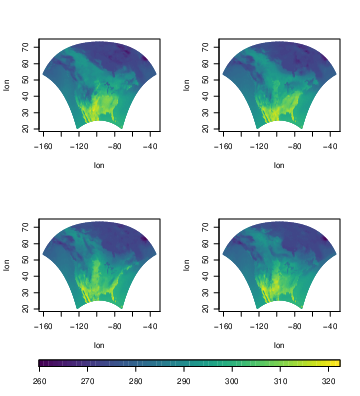

Figure 1: A heat map for the first four days of the `narccap` data.

```r
autoimage(lon, lat, tasmax[,,1:4])
```

The outline of the United States and Mexico are somewhat noticeable in the images of Figure 1, but this would be easier to see if the relevant national borders of the countries were included. This is accomplished in Figure 2, which is created by specifying a map in the previous command:

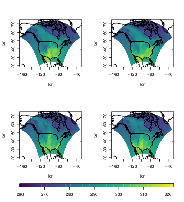

Figure 2: A heat map for the first four days of the `narccap` data, along with the relevant national borders.

```r
autoimage(lon, lat, tasmax[,,1:4], map = "world")
```

Images and heat maps can be created in R using functions from several different R packages. We discuss six functions in more detail. They are

1. the `image` function in the *graphics* package,
2. the `filled.contour` function in the *graphics* package,
3. the `image.plot` function in the [*fields*](https://CRAN.R-project.org/package=fields) package (Douglas Nychka et al. 2015),
4. the `levelplot` function in the [*lattice*](https://CRAN.R-project.org/package=lattice) package (Sarkar 2008),
5. the `spplot` function in the [*sp*](https://CRAN.R-project.org/package=sp) package (Pebesma and Bivand 2005; Bivand et al. 2015),
6. and the `geom_tile` function in the [*ggplot2*](https://CRAN.R-project.org/package=ggplot2) package (Wickham 2009).

In the next section, we compare the native capabilities of these tools with those of the *autoimage* package. We define the *native capabilities* of a function or package to be the capabilities of the function or package without loading additional packages or requiring additional user code. This will be followed by a section demonstrating the main capabilities of the *autoimage* package. We will conclude with a brief summary of conclusions in the final section.

## 2 Tools for creating heat maps in R

We now compare the capabilities of existing tools for creating heat maps in R.

We begin by discussing the `image` function included in the *graphics* package. This function is included in a standard R installation. The `image` function produces an image without a color scale. While one can discern spatial patterns from the plotted image, one cannot determine the magnitude of the response values without knowing more about the coloring scheme. Naturally, members of the R community have provided solutions to add this functionality. For example, the [*spatstat*](https://CRAN.R-project.org/package=spatstat) package (Baddeley and Turner 2005) extends the `image` function using S3 methods to automatically include a color scale with the image when an `im` class object is plotted. The `image` function requires the responses to be on a *regular grid*. Specifically, if $x$ and $y$ are each an increasing sequence of values, then the coordinates of a regular grid are obtained by considering all combinations of the elements in $x$ and $y$. Regular grids frequently become irregular when rotated or transformed to a different coordinate system. This is common for longitude/latitude coordinates that are transformed using a projection. When a matrix of images is desired, the user can modify the `mfrow` argument of the `par` function in the *graphics* package and then plot a sequence of images. However, the matrix of images will not include individual color scales or a common color scale. The `image` function has no capabilities related to coordinate projection. Existing images can be added to using standard *graphics* functions such as `lines` and `points`. It is worth noting that the standard R installation also includes a `heatmap` function in the *stats* package, but this displays a different result than the `image` function. The `heatmap` function documentation indicates that the `heatmap` function produces, “... a false color image ... with a dendrogram added to the left side and to the top. Typically, reordering of the rows and columns according to some set of values (row or column means) within the restrictions imposed by the dendrogram is carried out.” Consequently, a heat map is sometimes called an *image plot* by researchers whose data analysis is primarily done in R. We will continue to use the more general terminology “heat map” to describe this type of graphic in what follows.

The `filled.contour` function in the *graphics* package produces an image with a vertical color scale on the right side of the image. The algorithm used to color the polygons in the `filled.contour` function differs slightly from the `image` function, but produces similar results. The `filled.contour` function requires the responses to be on a regular grid. The `filled.contour` function cannot natively produce a sequence of heat maps with a common color scale or individual color scales because the function internally calls the `layout` function. Coordinate projection is not natively supported by the `filled.contour` function. An existing image can be added to using *graphics* functions such as `lines`, `points`, or `text`.

Another popular tool for creating heat maps in R is the `image.plot` function in the *fields* package. The `image.plot` function retains the strengths of the `image` function while providing additional functionality. The `image.plot` function automatically includes a color scale with the plotted image. More uniquely, the `image.plot` function can natively produce heat maps for data observed on an “irregular grid”. Let `x` be an $r\times c$ matrix of $x$ coordinates and `y` be an $r\times c$ matrix of $y$ coordinates. Then `x` and `y` define an irregular grid if `x[i,j]`$\leq$`x[i+1,j]`, `y[i,j]`$\leq$`y[i+1,j]`, `x[i,j]`$\leq$ `x[i,j+1]`, and `y[i,j]`$\leq$ `y[i,j+1]` for all valid choices of `i` and `j`. The `image.plot` function can be used to construct a matrix of heat maps with individual color scales by specifying the `mfrow` argument of the `par` function and calling `image.plot` the desired number of times. The `image.plot` function cannot natively create a matrix of images with a common color scale. Though the `image.plot` function includes functionality to create images for geographically-referenced irregular grids, it does not include any native functionality for projecting coordinates. Features can be added to existing images using the `lines`, `points`, and related functions.

The *lattice* package provided the first well-known alternative to the base graphics system in R. The *lattice* package produces heat maps using the `levelplot` function. Images produced by the `levelplot` function automatically include a color scale. The `levelplot` function can only produce heat maps for responses observed on a regular grid. The `levelplot` function can natively create a matrix of heat maps sharing a common color scale. To obtain a matrix of heat maps with individual color scales, one must combine a sequence of `levelplot` function calls with the `grid.arrange` function in the [*gridExtra*](https://CRAN.R-project.org/package=gridExtra) package (Auguie 2016). The `levelplot` function includes no functionality related to coordinate projection. Adding lines, points, or other features is usually accomplished by defining an appropriate panel function.

The *sp* package provides powerful classes for representing geographically-referenced data. The *sp* package can produce heat maps automatically for `SpatialGriddedDataFrame` class objects using the `spplot` function. The `spplot` function produces heat maps by extending the `levelplot` function in the *lattice* package, and the two functions have similar feature sets. One major difference between the two functions is that the *sp* package includes coordinate projection information within the `SpatialGriddedDataFrame`, so the `spTransform` function in the *sp* package can be used to easily project coordinates to a different system. However, if the projected set of coordinates is not regular, the `spplot` function will no longer produce a heat map for the transformed data, but will instead produce a scatterplot of colored points with a related color scale.

The grammar of graphics plotting system implemented in the *ggplot2* package continues to grow in popularity. A heat map can be constructed using *ggplot2* by combining the `geom_tile` geometry (or the `geom_rect` or `geom_raster` geometries) with a `ggplot` object. The heat map automatically includes a color scale with the image. Similar to the `image`, `levelplot`, and `spplot` functions, the *ggplot2* package requires locations to be on a regular grid. A matrix of images sharing a common color scale can be created directly in *ggplot2* using `facet_wrap` or `facet_grid`. A matrix of heat maps with individual color scales can be created by supplementing *ggplot2* with additionality functionality provided by the *gridExtra* or [*cowplot*](https://CRAN.R-project.org/package=cowplot) (Wilke 2016) packages. The `coord_map` function can be used to natively project geographic coordinates on a regular grid to an irregular grid. Additional features can be added to the images by specifying the appropriate geometry calls when creating the heat maps. These additional features are automatically projected if the `coord_map` function is utilized.

The *autoimage* package was created to easily produce a sequence of heat maps while natively working with projected coordinates, even when the data are not on a regular grid. The *autoimage* package utilizes the base R graphics system (like the `image`, `filled.contour`, and `image.plot` functions) to quickly and straightforwardly create heat maps. The `autoimage` function is the most important function in the *autoimage* package. The `autoimage` function automatically supplies a color scale with the constructed image(s). The `autoimage` function can automatically create heat maps for responses on an irregular grid, similar to the `image.plot` function. In fact, the *autoimage* function relies on the `poly.image` function from the *fields* package to create heat maps for this type of data, which is the function used by the `image.plot` function for the same purpose. Additionally, the *autoimage* package can natively create heat maps for non-gridded data by automatically interpolating the surface onto a regular grid before plotting using the [*akima*](https://CRAN.R-project.org/package=akima) package[^1] (Akima and Gebhardt 2016). The `autoimage` function can create a matrix of heat maps with either individual or shared color scales automatically, without the use of additional user code or R packages. Additionally, functionality for coordinate projection is available automatically in the `autoimage` function using the `mapproject` function in the [*mapproj*](https://CRAN.R-project.org/package=mapproj) package (McIlroy 2015). Additional features can be added to the plotted images (even for projected coordinates) using the `plines`, `ppoints`, `ptext`, and related functions available in the *autoimage* package.

We now summarize the similarities and differences between the *native functionality* of the *autoimage* package and the previous tools discussed. Most of the tools automatically include a color scale with the plotted image, similar to the `autoimage` function. The *lattice*, *sp*, and *ggplot2* packages can create a sequence of heat maps with a common color scale. The `image.plot` function can be used in combination with the `par` function to create a matrix of heat maps with individual color scales. The *lattice*, *sp*, and *ggplot2* packages can be used in combination with the *gridExtra* package to produce a matrix of heat maps with individual color scales. The `autoimage` function has native functionality for creating a matrix of heat maps with either a common or individual color scales. In contrast, only the `autoimage` and `image.plot` functions can *natively* create heat maps for data on an irregular grid. Additionally, only the `autoimage` package can *natively* create heat maps for non-gridded data (by automatically interpolating the responses onto a regular grid before plotting). The *sp*, *ggplot2*, and *autoimage* packages support coordinate projection of longitude/latitude coordinates, though only the *ggplot2* and *autoimage* packages can produce heat maps if the projected coordinates result in an irregular grid. Table 1 summarizes the features of the heat map-generating tools mentioned above. If a feature is not natively available, but becomes available by using a relevant package or function, then the appropriate tool is listed.

Table 1: Feature comparison for several functions and packages used for creating heat maps. “x” indicates the tool natively includes that feature. A function or package name indicates that the functionality is easily obtainable using that function or package.

| Package or function name | Color scale | Irregular grid | Non-gridded data | Shared color scale | Individual color scales | Coordinate projection |
| --- | --- | --- | --- | --- | --- | --- |
| `image` |  |  |  |  |  |  |
| `filled.contour` | x |  |  |  |  |  |
| *fields* | x | x |  |  | `par` |  |
| *lattice* | x |  |  | x | *gridExtra* |  |
| *sp* | x |  |  | x | *gridExtra* | x |
| *ggplot2* | x |  |  | x | *gridExtra* | x |
| *autoimage* | x | x | x | x | x | x |

The feature set for creating heat maps using the *ggplot2* package largely overlaps with the *autoimage* package, especially if additional packages are used to extend the functionality of *ggplot2*. A user may wonder whether the the *autoimge* package has any other advantages that would support its use over the more well-known and broadly capable *ggplot2* package. As previously mentioned, *ggplot2* requires that the original (unprojected) data be observed on a regular grid, while the *autoimage* package supports heat map creation for data on regular and irregular grids, as well as non-gridded data. Another advantage of the *autoimage* package is that it renders a sequence of heat maps for projected coordinates faster than the *ggplot2* package. In order to compare the speed of heat map generation using the *autoimage* and *ggplot2* packages when natively projecting the coordinates before plotting, we constructed a matrix of 36 heat maps (with a common color scale) using coordinates observed on a regular 116$\times$50 grid and projected the coordinates using the Lambert projection. Creating the heat maps on a mid-2012 MacBook Pro with a 2.6 GhZ Intel Core i7 processor and 16 GB of RAM took roughly 4 *seconds* using the *autoimage* package, but over 12 *minutes* using the *ggplot2* package. This is by no means an exhaustive timing comparison, but the result suggests that when coordinate projections are utilized in creating a matrix of heat maps, the *autoimage* package can render the plot more quickly than the *ggplot2* package.

## 3 *autoimage* examples

We now examine the capabilities of the *autoimage* package in more detail. The most important functions in *autoimage* are the `pimage` and `autoimage` functions. We illustrate the basic usage of these functions using two data sets: the first is the irregularly-gridded `narccap` data previously discussed, while the second is a set of non-gridded geochemical measurements for 960 locations in the state of Colorado. The Colorado geochemical measurements were obtained by the United States Geological Survey (USGS) as a baseline for the natural variation in soil geochemistry in Colorado (Smith and Ellefsen 2010) . The data are stored as a data frame with 960 rows and 31 columns. `easting`, `northing`, `latitude`, and `longitude` variables are provided in the data frame, as well as Aluminum (`Al`), Calcium (`Ca`), Iron (`Fe`), and many more chemical measurements. The Colorado data are available in the `co` data set in the [*gear*](https://CRAN.R-project.org/package=gear) package (French 2015).

The `autoimage` function is a generalization of the `pimage` function, so we discuss the `pimage` function first.

### 3.1 Basic usage of the pimage function

The most important arguments of the `pimage` function are `x`, `y`, and `z`. `x` and `y` are the coordinate locations and `z` is the responses associated with the coordinates. `x`, `y`, and `z` can have differing formats depending on the type of data to be plotted. If the data are observed on a regular grid, then `z` will be a matrix with dimensions matching the dimensions of the grid and `x` and `y` will be vectors of increasing values that define the grid lines. If the data are observed on an irregular grid, then `z` will be a matrix with dimensions matching the dimensions of the grid, and `x` and `y` will be matrices whose coordinates specify the $x$ and $y$ coordinates of each value in `z`. If the data are not on a grid, then `x` and `y` will be vectors specifying the coordinate locations, and `z` will be the vector of responses at each coordinate. If the data are not on a grid, then the data are automatically interpolated onto a grid before plotting. The command

```r
pimage(x = lon, y = lat, z = tasmax[,,1])
```

is used to create a heat map of the tasmax measurements for the first day of the `narccap` data. This heat map is shown in Figure 3. Recall that the `narccap` data are observed on an irregular grid.

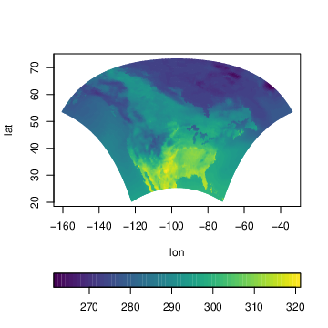

Figure 3: A heat map of the tasmax measurements for the first day of the `narccap` data.

A heat map of the Aluminum measurements for the non-gridded `co` data set is created by executing the commands

```r
data(co, package = 'gear')
pimage(co$longitude, co$latitude, co$Al)
```

with the resulting heat map shown in Figure 4.

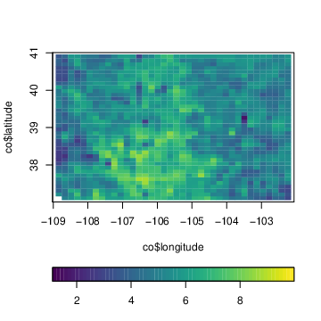

Figure 4: A heat map of the Aluminum measurements for the `co` data set.

We now discuss other basic arguments used by the `pimage` function.

The first two arguments we discuss are the `col` and `legend` arguments. The color scheme used for coloring a heat map is of great importance. The default color scheme used in the *autoimage* package is the `viridis` color scheme from the [*viridisLite*](https://CRAN.R-project.org/package=viridisLite) package. This color scheme is, “…designed in such a way that [it] will analytically be perfectly perceptually-uniform, both in regular form and also when converted to black-and-white. [It is] also designed to be perceived by readers with the most common form of color blindness.” (Garnier 2016) The color scale can be modified by passing a vector of colors to the `col` argument through the ellipses argument (`...`), as in the `image` function in the *graphics* package. The orientation of the color scale can be changed using the `legend` argument. The default value is `legend = ’horizontal’`, which produces a color scale horizontally underneath the image. The color scale can be removed by specifying `legend = ’none’` or can be placed vertically along the right side of the image by specifying `legend = ’vertical’`. A heat map of the first day of `narccap` tasmax measurements with a vertical color scale using 6 colors from the magma color palette in the *viridisLite* package is created by executing the command

```r
pimage(lon, lat, tasmax[,,1], col = viridisLite::magma(6), legend = 'vertical')
```

The resulting heat map is shown in Figure 5.

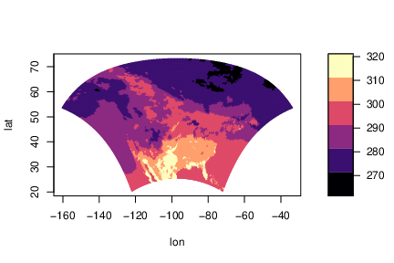

Figure 5: A heat map of the tasmax measurements for the first day of the `narccap` data using a custom color scheme and vertical color scale.

We now discuss arguments related to coordinate projection and adding geographic maps to an image. Longitude and latitude coordinates can be projected before plotting by specifying the `proj`, `parameters`, and `orientation` arguments. When specified, the coordinates are projected using the `mapproject` function in the *mapproj* package. `proj` specifies the name of the projection to utilize (the default is `’none’`, i.e. no projection). The `parameters` argument specifies the parameter values of the chosen projection, and `orientation` can be used to change the orientation of the projection. See the `mapproject` function in the *mapproj* function for more details regarding these arguments. Several geographic maps can be automatically added to the image by specifying the `map` argument. The available geographic maps come from the [*maps*](https://CRAN.R-project.org/package=maps) package (Brownrigg et al. 2016), and include the `world`, `usa`, `state`, `county`, `france`, `nz` (New Zealand), `italy`, `lakes`, and `world2` maps. Interested users can find more details about these maps in the *maps* package. We now create a heat map with projected coordinates for the first day of `narccap` tasmax measurements. We utilize the Bonne projection using 45 degrees as the standard parallel. We also add a geographic map of the continental United States (U.S.). Note that a grid is automatically added to the image because latitude and longitude parallels are not straight for most projections. The command

```r
pimage(lon, lat, tasmax[,,1], proj = 'bonne', parameters = 45, map = 'usa')
```

produces the heat map in Figure 6.

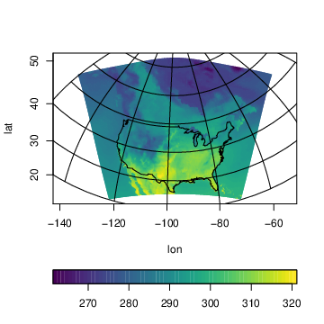

Figure 6: A heat map of the tasmax measurements for the first day of the `narccap` data using projected coordinates with an added geographic map of the continental U.S.

The last major argument to the `pimage` function is the `lratio` argument. This argument controls the relative height or width of the color scale in comparison with the main plotting area. Increasing `lratio` increases the thickness of the color scale, while decreasing `lratio` decreases the thickness of the color scale.

Additional customizations to heat maps produced by the `pimage` function can be made via the ellipses (`...`) argument. This includes adding custom geographic maps and points to the image, customizing the grid lines created when the coordinates are projected, further customizing the appearance of the color scale, and customizing the axis labels. These customizations are discussed in detail in the vignette included in the *autoimage* package, which can be accessed by executing the command `vignette(’autoimage’)`.

### 3.2 Basic usage of the autoimage function

We next discuss the `autoimage` function, which generalizes the `pimage` function to create a heat map with a sequence of images. The arguments for the `autoimage` and `pimage` functions are mostly the same, and we replicate their discussion only when necessary.

The structure of the `z` argument for the `autoimage` function may vary slightly from the `pimage` function. Specifically, if multiple gridded images are to be constructed, then `z` will be a three-dimensional array instead of a matrix. Each element of the third dimension of `z` corresponds to the matrix of gridded values for each image. If images for multiple non-gridded variables are to be constructed, then `z` will be a matrix where each column corresponds to a different variable. The `autoimage` function automatically constructs a sequence of images with a common color scale. If individual color scales are desired for each image, then the `common.legend` argument can be set to `FALSE`. The `size` argument can be used to specify the layout of the sequence of images, similar to the `mfrow` argument of the `par` function in the *graphics* package. If this is not specified, the `autosize` function in the *autoimage* package is used to automatically choose the layout, with a tendency to produce a layout closer to square dimensions. We produce a 1$\times$3 matrix of images with a common color scale for the `narccap` data using the command

```r
autoimage(lon, lat, tasmax[,,1:3], size = c(1, 3))
```

as shown in Figure 7.

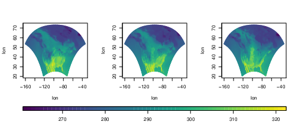

Figure 7: A heat map of the `narccap` data set tasmax measurements in a 1$\times$3 layout.

Similarly, we create a 2$\times$2 layout of images for the Colorado geochemical measurements by passing 4 columns of the `co` data frame to the `autoimage` function. The values of each variable have substantially different ranges, so we use individual color scales for each image. Titles are added to each image using the `main` argument by providing a character vector whose length matches the number of plotted images. Executing the command

```r
autoimage(co$lon, co$lati, co[,c('Al', 'Ca', 'Fe', 'K')], common.legend = FALSE,
          main = c('(a) Aluminum %', '(b) Calcium %', '(c) Iron %', '(d) Potassium %'))
```

produces Figure 8.

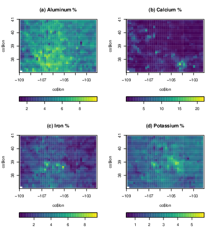

Figure 8: A heat map of various geochemical measurements taken in Colorado.

It is natural to add a common title to a heat map with multiple images. This can be accomplished by passing the desired title to the `outer.title` argument. The title will be added in the outer margin of the resulting heat map. The size of the outer margins should be specified using the `oma` argument of the `par` function of the *graphics* package before adding the common title. However, a sensible choice for the size of the outer margins is automatically made by the `autoimage` package if this is not specified by the user. We create the heat map of `narccap` tasmax measurements shown in Figure 9 by executing the command

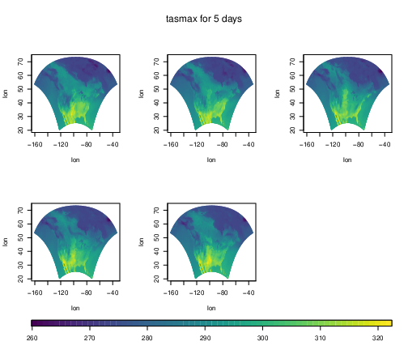

Figure 9: A heat map of the NARCCAP tasmax measurements with a common title.

```r
autoimage(lon, lat, tasmax, outer.title = 'tasmax for 5 days')
```

Additional customizations to heat maps produced by the `autoimage` function can be made via the ellipses (`...`) argument. In addition to the customizations mentioned in the context of the `pimage` function, this includes the ability to change the appearance of the common title. These customizations are discussed in detail in the vignette included in the *autoimage* package, which can be accessed by executing the command `vignette(’autoimage’)`.

### 3.3 Richer plots using the autolayout and autolegend functions

Suppose we want to add custom features to a sequences of images, with each image receiving different features. One can create a richer sequence of images using the `autolayout` and `autolegend` functions.

The `autolayout` function partitions the graphic device into the sections needed to create a sequence of images. The most important function arguments include `size`, `legend`, `common.legend`, and `lratio`, which correspond to the same arguments in the `pimage` and `autoimage` functions. The `outer` argument specifies whether a common title will be utilized in the plot. The default is `outer = FALSE`, indicating that no common title will be added to the plot. When `autolayout` is called, numbers identify the plotting order of the sections, though these can be hidden by setting `show = FALSE`. As an initial example, we create a 2$\times$3 matrix of images with a common vertical color scale. The command

```r
autolayout(c(2, 3), legend = 'v')
```

produces the plot in Figure 10.

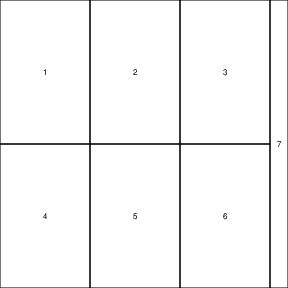

Figure 10: A 2$\times$3 matrix of plotting regions with a common vertical legend created by the `autolayout` function.

After creating the layout of a complicated heat map using the `autolayout` function, the images should be created using the `pimage` function while specifying `legend = ’none’`. After the desired image or set of images is created, one can automatically add the appropriate legend by calling `autolegend`. The `autolegend` function recovers relevant color scale parameters from the most recent `pimage` call. Consequently, if a common legend is desired, it is important to specify a common `zlim` argument among all relevant `pimage` calls.

Various features can be added to the images using the `ppoints`, `plines`, `ptext`, `psegments`, `parrows`, and `ppolygon` functions. These are analogues of the `points`, `lines`, `text`, `segments`, `arrows`, and `polygon` functions in the *graphics* package, to be used with images containing projected coordinates.

We provide an (unrealistic, but informative) example of the kinds of plots these functions can be used to create. Suppose we wish to create a heat map for both the `narccap` and Colorado geochemical data sets. We desire to add a geographic map for each state in the U.S. for the `narccap` data while using the Mercator projection to transform the coordinates before plotting. We desire to plot the Aluminum measurements for the Colorado data. We want a custom color scale similar to the jet color scheme in Matlab. We desire to project the coordinates before plotting using the Bonne projection with a reference latitude of 39 degrees. We also desire to add geographic maps of the relevant U.S. counties to the map, along with labels for select Colorado cities. Lastly, we will add a large, purple title to the two heat maps.

We begin by obtaining some of the relevant information for these plots. The borders for the continental U.S. states is available in the `state` map in the *maps* package. However, we must extract the borders of Alaska and Hawaii from the `world` map in the *maps* package. Executing the commands

```r
data(worldMapEnv, package = 'maps')
hiak <- maps::map('world', c('USA:Hawaii', 'USA:Alaska'), plot = FALSE)
```

loads and extracts the borders for Hawaii and Alaska. The results are stored in a list named `hiak` with named vectors `x` and `y` containing the coordinates of the borders. Each state border is separated by an `NA` value. The commands

```r
data(us.cities, package = 'maps')
codf <- us.cities[us.cities$country.etc == 'CO', ]
codf <- codf[c(3, 5, 7:10, 18), ]
```

loads the `us.cities` data set from the *maps* package, extracts the Colorado cities from this data set, then stores a small sample of these Colorado cities in the `codf` data frame. Information related to the name, longitude, and latitude of each city is included in the data frame.

Having obtained the relevant information, we setup a 1$\times$2 matrix of images with individual horizontal color scales and an area for a common title using the command:

```r
autolayout(c(1, 2), legend = "h", common.legend = FALSE, outer = TRUE)
```

We now create a heat map for the first day of NARCCAP tasmax measurements using the command

```r
pimage(lon, lat, tasmax[,,1], legend = 'none', proj = 'mercator',
       map = 'state', lines.args = list(col = 'grey'))
```

Note that `legend = ’none’` since this will be added afterward using the `autolegend` function. The Mercator projection was chosen via the `proj` argument, and the `state` geographic map was added. The color of the geographic map was changed by passing the `lines.args` argument to `pimage`. The `lines.args` argument is a named list with components matching the arguments of the `lines` function in the *graphics* package, and changes the appearance of any geographic maps plotted using the `pimage` function. We next add the state borders for Hawaii and Alaska using the `plines` function, title the heat map, and add the color scale to the image by executing the following commands:

```r
plines(hiak, proj = 'mercator', col = 'grey')
title('tasmax for North America')
autolegend()
```

Note the specification of the projection and line color in the `plines` function call.

Next, we construct the image for the Colorado Aluminum measurements using the commands

```r
pimage(co$lon, co$lat, co$Al, map = 'county', legend = 'none',
       proj = 'bonne', parameters = 39, paxes.args = list(grid = FALSE),
       col = fields::tim.colors(64), lines.args = list(col = 'grey'))
```

Note the custom color scheme specified by the `col` argument. Also, the `paxes.args` argument is passed to the `pimage` function to suppress the grid lines that would normally be plotted when a projection is used. The locations and names of the Colorado cities are added to the image using the commands

```r
ppoints(codf$lon, codf$lat, pch = 16, proj = 'bonne')
ptext(codf$lon, codf$lat, labels = codf$name, proj = 'bonne', pos = 4)
```

A title and color scale are added to the image using the commands

```r
title('Colorado Aluminum levels (%)')
autolegend()
```

Lastly, we specify a large common title for the heat maps using the `mtext` function in the *graphics* package. Specifically, we execute the command:

```r
mtext('Two complicated maps', col = 'purple', outer = TRUE, cex = 2)
```

The plot resulting from the commands listed in this section is shown in Figure 11.

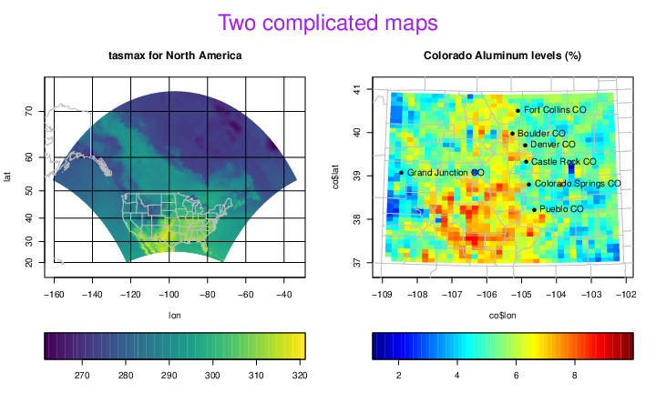

Figure 11: A complicated set of heat maps created using the `autolayout` and `autolegend` functions.

## 4 Summary

We have introduced the *autoimage* package for constructing heat maps. The *autoimage* package natively supports: 1. automatic inclusion of a color scale with the plotted image, 2. construction of heat maps for responses observed on regular or irregular grids, as well as non-gridded data, 3. construction of a matrix of heat maps with a common color scale, 4. construction of a matrix of heat maps with individual color scales, 5. projecting coordinates before plotting, 6. easily adding geographic borders, points, and other features to the heat maps. We believe that the breadth of native features, simplicity, and speed of the *autoimage* package make it a unique contribution to the R user community in comparison with other R tools that can be used for creating heat maps. We note however that the *autoimage* package is a specialized tool and is limited to the construction of heat maps. This is in contrast to other plotting packages mentioned earlier, such as the *lattice*, *sp*, and *ggplot2* packages, which have many plotting capabilities unrelated to heat maps.

A number of additional features and heat map customizations are available in the *autoimage* package, but were not discussed in order to shorten the length of this article. Additional discussion and examples may be found in the documentation of the *autoimage* package. A more detailed introduction to the capabilities of the *autoimage* package can be accessed by executing the command `vignette(’autoimage’)`. Additionally, a vignette comparing some of the heat map capabilities of the *autoimage* and *ggplot2* packages can be accessed be executing the command `vignette(’ggplot2-comparison’)`.

The source code for the *autoimage* package is publicly hosted at https://github.com/jpfrench81/autoimage. Bugs and other issues may be reported there. Additionally, interested parties are encouraged to submit improvements for the *autoimage* package at the GitHub repository listed above.

## 5 Acknowledgments

This *autoimage* package was created for research supported by NSF Grant DMS-1463642 and NIH Grant R01 CA157528. This package would not have been created without inspiration from the internals of the `image.plot` function in the *fields* package written by Doug Nychka and from the `image.scale.2` function written by Marc Taylor and discussed at http://menugget.blogspot.com/2013/12/new-version-of-imagescale-function.html.

### 5.1 CRAN packages used

autoimage, fields, lattice, sp, ggplot2, spatstat, gridExtra, cowplot, akima, mapproj, gear, viridisLite, maps

### 5.2 CRAN Task Views implied by cited packages

ChemPhys, NetworkAnalysis, NumericalMathematics, Phylogenetics, Spatial, SpatioTemporal, Survival, TeachingStatistics

H. Akima and A. Gebhardt. *Akima: Interpolation of irregularly and regularly spaced data.* 2016. URL https://CRAN.R-project.org/package=akima. R package version 0.6-2.

B. Auguie. *gridExtra: Miscellaneous functions for "grid" graphics.* 2016. URL https://CRAN.R-project.org/package=gridExtra. R package version 2.2.1.

A. Baddeley and R. Turner. Spatstat: An R package for analyzing spatial point patterns. *Journal of Statistical Software*, 12(6): 1–42, 2005. URL https://doi.org/10.18637/jss.v012.i06.

R. S. Bivand, E. Pebesma and V. Gómez-Rubio. *Applied spatial data analysis with R, Second edition.* Springer, NY, 2015. URL https://doi.org/10.1007/978-1-4614-7618-4. asdar-book.org.

R. Brownrigg, T. P. Minka and A. Deckmyn. *Maps: Draw geographical maps.* 2016. URL https://CRAN.R-project.org/package=maps. R package version 3.1.1.

D. Caya and R. Laprise. A semi-implicit semi-Lagrangian regional climate model: The Canadian RCM. *Monthly Weather Review*, 127(3): 341–362, 1999. URL https://doi.org/10.1175/1520-0493(1999)127<0341:ASISLR>2.0.CO;2.

M. Collins, B. B. Booth, G. R. Harris, J. M. Murphy, D. M. Sexton and M. J. Webb. Towards quantifying uncertainty in transient climate change. *Climate Dynamics*, 27(2-3): 127–147, 2006. URL https://doi.org/10.1007/s00382-006-0121-0.

Douglas Nychka, Reinhard Furrer, John Paige and Stephan Sain. Fields: Tools for spatial data. 2015. URL https://doi.org/10.5065/D6W957CT. R package version 8.10.

J. French. *Autoimage: Multiple heat maps for projected coordinates.* 2017. URL https://CRAN.R-project.org/package=autoimage. R package version 1.3.

J. French. *Gear: Geostatistical analysis in R.* 2015. URL https://CRAN.R-project.org/package=gear. R package version 0.1.1.

S. Garnier. *viridisLite: Default color maps from ’matplotlib’ (lite version).* 2016. URL https://CRAN.R-project.org/package=viridisLite. R package version 0.1.3.

D. McIlroy. *Mapproj: Map projections.* 2015. URL https://CRAN.R-project.org/package=mapproj. R package version 1.2-4. Packaged for R by Ray Brownrigg and Thomas P Minka and transition to Plan 9 codebase by Roger Bivand.

L. O. Mearns et al. The North American Regional Climate Change Assessment Program dataset, National Center for Atmospheric Research Earth System Grid data portal. 2007, updated 2014. URL https://doi.org/10.5065/D6RN35ST. Boulder, CO. Data downloaded 2016-08-12.

L. O. Mearns, R. Arritt, S. Biner, M. S. Bukovsky, S. McGinnis, S. Sain, D. Caya, J. Correia Jr, D. Flory, W. Gutowski, et al. The North American regional climate change assessment program: Overview of phase i results. *Bulletin of the American Meteorological Society*, 93(9): 1337–1362, 2012. URL https://doi.org/10.1175/BAMS-D-11-00223.1.

L. O. Mearns, W. Gutowski, R. Jones, R. Leung, S. McGinnis, A. Nunes and Y. Qian. A regional climate change assessment program for North America. *EOS, Transactions American Geophysical Union*, 90(36): 311–311, 2009. URL https://doi.org/10.1029/2009EO360002.

E. J. Pebesma and R. S. Bivand. Classes and methods for spatial data in R. *R News*, 5(2): 2005. URL http://cran.r-project.org/doc/Rnews/.

D. Sarkar. *Lattice: Multivariate data visualization with r.* New York: Springer-Verlag, 2008. URL https://doi.org/10.1007/978-0-387-75969-2. ISBN 978-0-387-75968-5.

D. B. Smith and K. J. Ellefsen. Soil geochemical data for the Wyoming landscape conservation initiative study area: Data series 510. U.S. Geological Survey. 2010. http://pubs.usgs.gov/ds/510/.

H. Wickham. *ggplot2: Elegant graphics for data analysis.* Springer-Verlag, 2009. URL https://doi.org/10.1007/978-0-387-98141-3. http://ggplot2.org.

C. O. Wilke. *Cowplot: Streamlined plot theme and plot annotations for ’ggplot2’.* 2016. URL https://CRAN.R-project.org/package=cowplot. R package version 0.7.0.

[^1]: The *akima* package has a restrictive license and must be installed manually. We plan to replace *akima* with a package offering similar functionality, but a with more permissive license, in a future *autoimage* release.